# Practical I

## The simulation framework

### Install

Borrow from Thompson et al. (2020) and slightly modified.

To install from GitHub

```r
devtools::install_github("mxdub/TMDSpatial")
```

### Use

Function is quickly described on GitHub - see Thompson et al. (2020) for details on implementation. The overall idea :

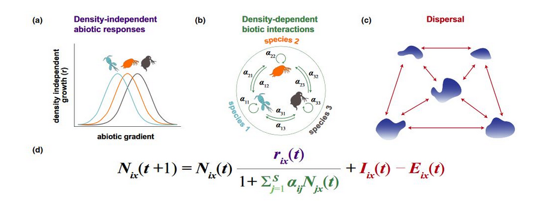

We are going to use only the simulation function : *simulate_MC()*. All parameters can be view in the help (?simulate_MC()). Main parameters are already set for our use here.

The typical use of that function :

```r
library(TMDSpatial)
# Some additional packages might be needed:
library(tidyverse)
library(vegan)

n_patch = 250
n_species = 5

sim = simulate_MC(patches = n_patch,     # Number of patch
                  species = n_species,   # Number of species
                  env1Scale = 100,         # Spatial autocorrelation for environmental variable
                                          # (from large autocorrelation to no autocorr. - e.g. 0.01 to 100)
                  env_niche_breadth = 1, # Species environmental niche breadth (can be a vector)
                  kernel_exp = 0.2)      # Rate of decrease of disp. kernel (e.g. P(disp) = exp(-kernel_exp*dist(i,j)))
```

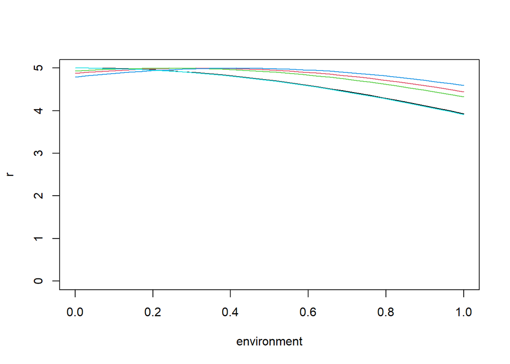

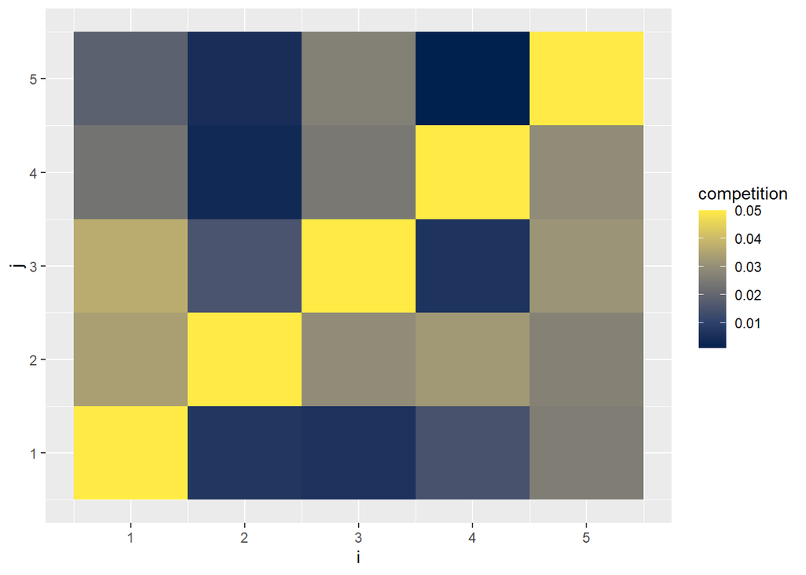

At the end of simulation. Two plots are displayed - (i) species ‘environmental niche’, (ii) interaction matrix.

In this case; environmental niche breadth are large (env_niche_breadth = 1), environment is not auto-correlated in space and dispersal is limited.

The dispersal kernel :

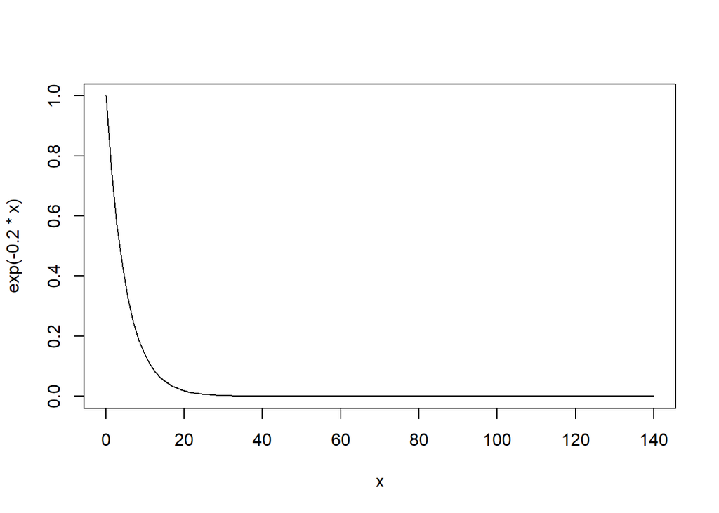

```r
curve(exp(-0.2*x), xlim = c(0,140)) # Max distance among patch is ca. 140 units
```

You can also plot patches in space, with their environmental value to see how environmental values are clustered in space.

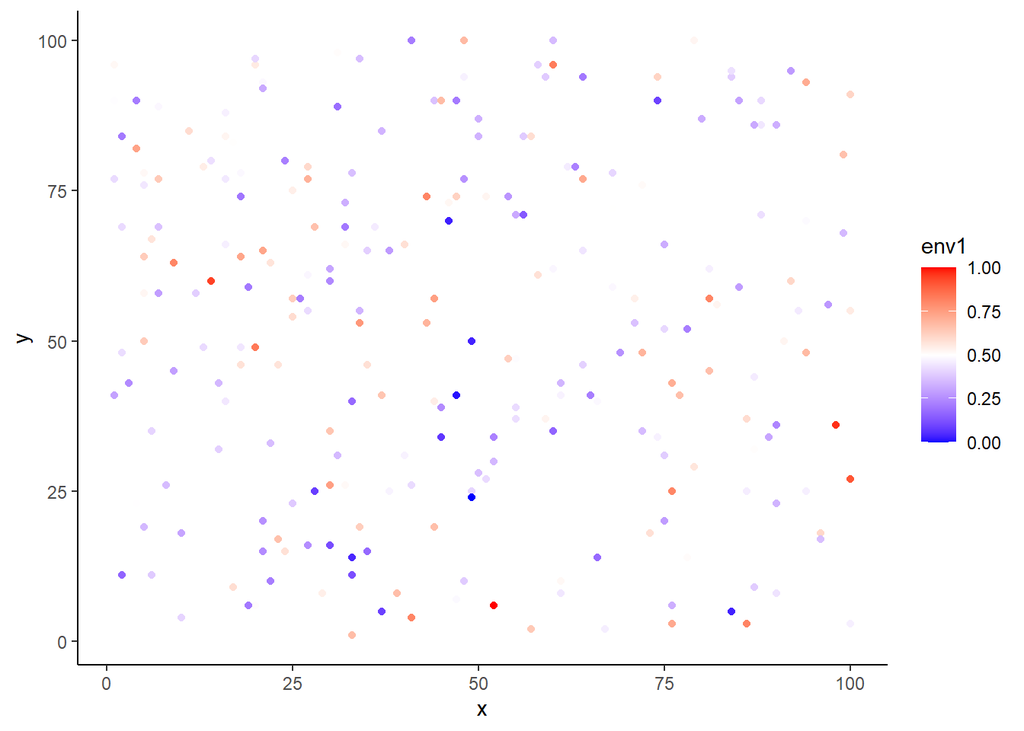

```r
plots_envt(sim)
```

In the end, you also have some helper functions to gather some data from the simulation output :

To get environmental values and geographical positions :

```r
data_envt = get_envt(sim)
data_geo = get_geoposition(sim)
```

And to get abundances and/or occupancies (i.e. presence/absence)

```r
abundances = sim_to_matrix(sim)
occupancies = abund_to_occ(abundances)
```

And lastly, it’s possible to plot directly occupancies over time for all species:

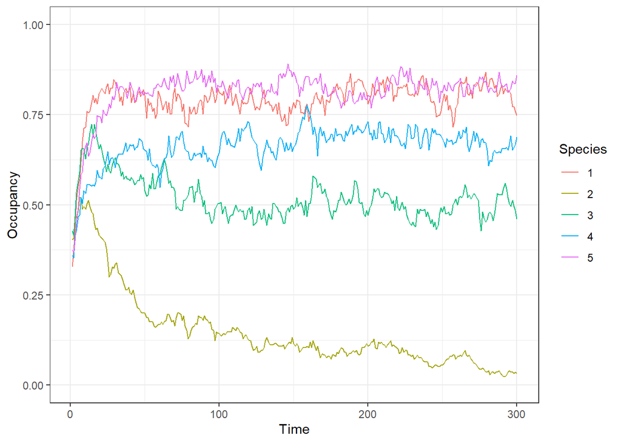

```r
plots_occupancies(occupancies)
```

## Variation partitioning approach

### (ecological) Distances measures

Several distances measures can be used for ordinations. They vary in how (relatives) abundances are considered, and whether more weight is put on rare or common species. They also condition the ordination method that can be used.

As a rule of thumb:

- Bray-Curtis distance : If absolute abundances differences are important
- Hellinger distance : If relative abundances differences are important - and common species important
- Chi square distance : If relative abundances differences are important - and rare species important

The same distances can be used for binary data (in particular, Bray-Curtis distance is equivalent to Sorensen dissimilarity)

Some ordination methods works on *raw* data (eventually transformed - e.g., Hellinger transformed) (e.g., (constrained) Canonical Analysis, rda), whereas other works on distances (e.g., PCoA, dbRDA).

For the following, we will only use Hellinger and Bray-Curtis distances with associated methods (rda(), and dbrda(), as we will be interested in constrained analysis, and partition of variance).

### (spatial) Predictors

Numerous methods exist to model space predictors, here, we will use PCNM (Principal Coordinates of Neighbourhood Matrix, Borcard & Legendre, 2002). The general idea is to start from the among-patch distance matrix, truncates larges distances (fixed to a constant), and run a PCA on resulting matrix. Only eigenvectors associated with positive eigenvalues are kept.

Pcnms can easily be obtained using {vegan} package :

```r
library(vegan)
dist_matrix = dist(data_geo)
pcnms = scores(pcnm(dist_matrix))
```

They represent autocorrelation at various scales… For example, the three first vectors :

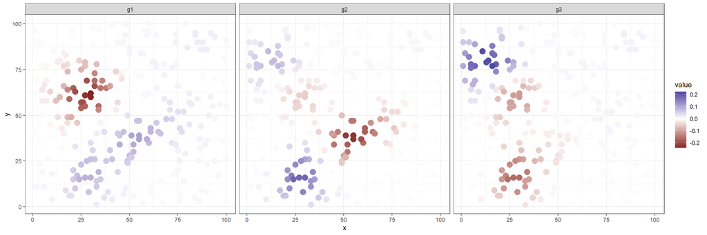

```r
dt = tibble(x = data_geo$x, y = data_geo$y, g1 = pcnms[,1], g2 = pcnms[,2], g3 = pcnms[,3]) %>%
  pivot_longer(-c(x,y), names_to = "PCNMs")

ggplot(dt, aes(x=x,y=y,color=value))+
  geom_point(size = 4)+
  facet_grid(.~PCNMs)+
  scale_color_gradient2()+
  theme_bw()
```

### Partionning the variance between environmental and geographical distances

Classic methods works on snapshot data (i.e. a community matrix, without temporal dimension). We are therefor going to select a ‘slice’ of the dataset (e.g., year 200).

```r
# taking time = 200
snapshot = t(abundances[,,200]) # Matrix is transpose (inverts rows / cols)
```

#### Using Hellinger distance

{Vegan} package propose a easy-to-use function to compute a partition of variance (varpart() function)

```r
vp = varpart( snapshot,
              ~env1+I(env1^2), # Why using square envt ?
              pcnms,
              data = data_envt, transfo = 'hel')

vp
```

```
##
## Partition of variance in RDA
##
## Call: varpart(Y = snapshot, X = ~env1 + I(env1^2), pcnms, data =
## data_envt, transfo = "hel")
## Species transformation:  hellinger
## Explanatory tables:
## X1:  ~env1 + I(env1^2)
## X2:  pcnms
##
## No. of explanatory tables: 2
## Total variation (SS): 95.491
##             Variance: 0.3835
## No. of observations: 250
##
## Partition table:
##                       Df R.squared Adj.R.squared Testable
## [a+c] = X1             2   0.01598       0.00801     TRUE
## [b+c] = X2           146   0.62879       0.10261     TRUE
## [a+b+c] = X1+X2      148   0.63538       0.10107     TRUE
## Individual fractions
## [a] = X1|X2            2                -0.00154     TRUE
## [b] = X2|X1          146                 0.09307     TRUE
## [c]                    0                 0.00955    FALSE
## [d] = Residuals                          0.89893    FALSE
## ---
## Use function 'rda' to test significance of fractions of interest
```

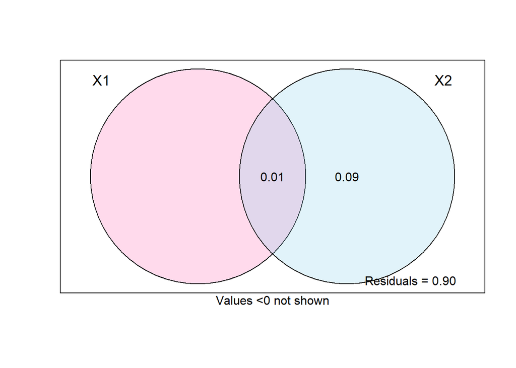

```r
plot(vp, bg = c("hotpink","skyblue"))
```

Variance explained (adjusted-R2, see Peres-Neto et al. (2006).) by each fractions are presented in the output from varpart(), and displayed in the plot.

In order to go further, and test individual parts, we rely on the associated method (here, rda for Hellinger transform).

##### Testing X1 & X2 fractions :

Is there a significant effect of X1 component (environmental variables) :

```r
frac_envt = rda(decostand(snapshot, "hel")~env1+I(env1^2),
                data = data_envt)
frac_envt
```

```
## Call: rda(formula = decostand(snapshot, "hel") ~ env1 + I(env1^2), data
## = data_envt)
##
##                Inertia Proportion Rank
## Total         0.383498   1.000000
## Constrained   0.006127   0.015975    2
## Unconstrained 0.377372   0.984025    5
## Inertia is variance
##
## Eigenvalues for constrained axes:
##     RDA1     RDA2
## 0.003730 0.002397
##
## Eigenvalues for unconstrained axes:
##     PC1     PC2     PC3     PC4     PC5
## 0.14715 0.11510 0.08183 0.02176 0.01152
```

```r
# Compare full model to reduced model (i.e. without explicative table)
anova(frac_envt)
```

```
## Permutation test for rda under reduced model
## Permutation: free
## Number of permutations: 999
##
## Model: rda(formula = decostand(snapshot, "hel") ~ env1 + I(env1^2), data = data_envt)
##           Df Variance     F Pr(>F)
## Model      2  0.00613 2.005  0.046 *
## Residual 247  0.37737
## ---
## Signif. codes:  0 '***' 0.001 '**' 0.01 '*' 0.05 '.' 0.1 ' ' 1
```

```r
# Previous Adjust R2 can be find with :
RsquareAdj(frac_envt)
```

```
## $r.squared
## [1] 0.01597545
##
## $adj.r.squared
## [1] 0.008007643
```

Is there a significant effect of X2 component (spatial variables - spatial autocorr.) :

```r
frac_spat = rda(decostand(snapshot, "hel")~.,
                data = as.data.frame(pcnms))
frac_spat
```

```
## Call: rda(formula = decostand(snapshot, "hel") ~ PCNM1 + PCNM2 + PCNM3
## + PCNM4 + PCNM5 + PCNM6 + PCNM7 + PCNM8 + PCNM9 + PCNM10 + PCNM11 +
## PCNM12 + PCNM13 + PCNM14 + PCNM15 + PCNM16 + PCNM17 + PCNM18 + PCNM19 +
## PCNM20 + PCNM21 + PCNM22 + PCNM23 + PCNM24 + PCNM25 + PCNM26 + PCNM27 +
## PCNM28 + PCNM29 + PCNM30 + PCNM31 + PCNM32 + PCNM33 + PCNM34 + PCNM35 +
## PCNM36 + PCNM37 + PCNM38 + PCNM39 + PCNM40 + PCNM41 + PCNM42 + PCNM43 +
## PCNM44 + PCNM45 + PCNM46 + PCNM47 + PCNM48 + PCNM49 + PCNM50 + PCNM51 +
## PCNM52 + PCNM53 + PCNM54 + PCNM55 + PCNM56 + PCNM57 + PCNM58 + PCNM59 +
## PCNM60 + PCNM61 + PCNM62 + PCNM63 + PCNM64 + PCNM65 + PCNM66 + PCNM67 +
## PCNM68 + PCNM69 + PCNM70 + PCNM71 + PCNM72 + PCNM73 + PCNM74 + PCNM75 +
## PCNM76 + PCNM77 + PCNM78 + PCNM79 + PCNM80 + PCNM81 + PCNM82 + PCNM83 +
## PCNM84 + PCNM85 + PCNM86 + PCNM87 + PCNM88 + PCNM89 + PCNM90 + PCNM91 +
## PCNM92 + PCNM93 + PCNM94 + PCNM95 + PCNM96 + PCNM97 + PCNM98 + PCNM99 +
## PCNM100 + PCNM101 + PCNM102 + PCNM103 + PCNM104 + PCNM105 + PCNM106 +
## PCNM107 + PCNM108 + PCNM109 + PCNM110 + PCNM111 + PCNM112 + PCNM113 +
## PCNM114 + PCNM115 + PCNM116 + PCNM117 + PCNM118 + PCNM119 + PCNM120 +
## PCNM121 + PCNM122 + PCNM123 + PCNM124 + PCNM125 + PCNM126 + PCNM127 +
## PCNM128 + PCNM129 + PCNM130 + PCNM131 + PCNM132 + PCNM133 + PCNM134 +
## PCNM135 + PCNM136 + PCNM137 + PCNM138 + PCNM139 + PCNM140 + PCNM141 +
## PCNM142 + PCNM143 + PCNM144 + PCNM145 + PCNM146, data =
## as.data.frame(pcnms))
##
##               Inertia Proportion Rank
## Total          0.3835     1.0000
## Constrained    0.2411     0.6288    5
## Unconstrained  0.1424     0.3712    5
## Inertia is variance
##
## Eigenvalues for constrained axes:
##    RDA1    RDA2    RDA3    RDA4    RDA5
## 0.09390 0.07461 0.04924 0.01568 0.00771
##
## Eigenvalues for unconstrained axes:
##     PC1     PC2     PC3     PC4     PC5
## 0.05696 0.04104 0.03468 0.00590 0.00376
```

```r
# Compare full model to reduced model (i.e. without explicative table)
anova(frac_spat)
```

```
## Permutation test for rda under reduced model
## Permutation: free
## Number of permutations: 999
##
## Model: rda(formula = decostand(snapshot, "hel") ~ PCNM1 + PCNM2 + PCNM3 + PCNM4 + PCNM5 + PCNM6 + PCNM7 + PCNM8 + PCNM9 + PCNM10 + PCNM11 + PCNM12 + PCNM13 + PCNM14 + PCNM15 + PCNM16 + PCNM17 + PCNM18 + PCNM19 + PCNM20 + PCNM21 + PCNM22 + PCNM23 + PCNM24 + PCNM25 + PCNM26 + PCNM27 + PCNM28 + PCNM…
##     PCNM53 + PCNM54 + PCNM55 + PCNM56 + PCNM57 + PCNM58 + PCNM59 + PCNM60 + PCNM61 + PCNM62 + PCNM63 + PCNM64 + PCNM65 + PCNM66 + PCNM67 + PCNM68 + PCNM69 + PCNM70 + PCNM71 + PCNM72 + PCNM73 + PCNM74 + PCNM75 + PCNM76 + PCNM77 + PCNM78 + PCNM79 + PCNM80 + PCNM81 + PCNM82 + PCNM83 + PCNM84 + PCNM8…
##     PCNM108 + PCNM109 + PCNM110 + PCNM111 + PCNM112 + PCNM113 + PCNM114 + PCNM115 + PCNM116 + PCNM117 + PCNM118 + PCNM119 + PCNM120 + PCNM121 + PCNM122 + PCNM123 + PCNM124 + PCNM125 + PCNM126 + PCNM127 + PCNM128 + PCNM129 + PCNM130 + PCNM131 + PCNM132 + PCNM133 + PCNM134 + PCNM135 + PCNM136 + PCN…
##           Df Variance     F Pr(>F)
## Model    146  0.24114 1.195  0.036 *
## Residual 103  0.14236
## ---
## Signif. codes:  0 '***' 0.001 '**' 0.01 '*' 0.05 '.' 0.1 ' ' 1
```

```r
# Previous Adjust R2 can be find with :
RsquareAdj(frac_spat)
```

```
## $r.squared
## [1] 0.6287923
##
## $adj.r.squared
## [1] 0.1026144
```

##### Are these fraction still significant once accounted for shared effects ? (partial RDA)

Is there a significant effect of X1 component (environmental variables) independently of X2 :

```r
frac_envt_indp = rda(decostand(snapshot, "hel")~env1+I(env1^2)+Condition(pcnms),
                data = data_envt)
frac_envt_indp
```

```
## Call: rda(formula = decostand(snapshot, "hel") ~ env1 + I(env1^2) +
## Condition(pcnms), data = data_envt)
##
##                Inertia Proportion Rank
## Total         0.383498   1.000000
## Conditional   0.241141   0.628792  146
## Constrained   0.002525   0.006583    2
## Unconstrained 0.139833   0.364624    5
## Inertia is variance
##
## Eigenvalues for constrained axes:
##      RDA1      RDA2
## 0.0017867 0.0007380
##
## Eigenvalues for unconstrained axes:
##     PC1     PC2     PC3     PC4     PC5
## 0.05591 0.04068 0.03388 0.00565 0.00371
```

```r
# Compare full model to reduced model (i.e. without condition table)
anova(frac_envt_indp)
```

```
## Permutation test for rda under reduced model
## Permutation: free
## Number of permutations: 999
##
## Model: rda(formula = decostand(snapshot, "hel") ~ env1 + I(env1^2) + Condition(pcnms), data = data_envt)
##           Df Variance      F Pr(>F)
## Model      2 0.002525 0.9118  0.492
## Residual 101 0.139833
```

```r
# Previous Adjust R2 can be find with :
RsquareAdj(frac_envt_indp)
```

```
## $r.squared
## [1] 0.006583328
##
## $adj.r.squared
## [1] -0.001539827
```

Is there a significant effect of X2 component (spatial variables) independently of X1 :

```r
frac_spat_indp = rda(decostand(snapshot, "hel")~Condition(env1+I(env1^2))+pcnms,
                data = data_envt)
frac_spat_indp
```

```
## Call: rda(formula = decostand(snapshot, "hel") ~ Condition(env1 +
## I(env1^2)) + pcnms, data = data_envt)
##
##                Inertia Proportion Rank
## Total         0.383498   1.000000
## Conditional   0.006127   0.015975    2
## Constrained   0.237539   0.619400    5
## Unconstrained 0.139833   0.364624    5
## Inertia is variance
##
## Eigenvalues for constrained axes:
##    RDA1    RDA2    RDA3    RDA4    RDA5
## 0.09164 0.07466 0.04751 0.01596 0.00777
##
## Eigenvalues for unconstrained axes:
##     PC1     PC2     PC3     PC4     PC5
## 0.05591 0.04068 0.03388 0.00565 0.00371
```

```r
# Compare full model to reduced model (i.e. without condition table)
anova(frac_spat_indp)
```

```
## Permutation test for rda under reduced model
## Permutation: free
## Number of permutations: 999
##
## Model: rda(formula = decostand(snapshot, "hel") ~ Condition(env1 + I(env1^2)) + pcnms, data = data_envt)
##           Df Variance      F Pr(>F)
## Model    146  0.23754 1.1752  0.053 .
## Residual 101  0.13983
## ---
## Signif. codes:  0 '***' 0.001 '**' 0.01 '*' 0.05 '.' 0.1 ' ' 1
```

```r
# Previous Adjust R2 can be find with :
RsquareAdj(frac_spat_indp)
```

```
## $r.squared
## [1] 0.6194002
##
## $adj.r.squared
## [1] 0.09306696
```

##### Variable selection ?

Here, all variables were kept in both table. But, some table have numerous variable (especially with the PCNMs), thus, it might be desirable to select only some of them. Once again, {vegan} propose a convenient function for that purpose :

```r
# Define a null and full model

mod0 = rda(decostand(snapshot, "hel") ~ 1, data = as_tibble(pcnms))
mod1 = rda(decostand(snapshot, "hel") ~ ., data = as_tibble(pcnms))
os = ordistep(mod0, scope = formula(mod1)) # Compare model using AIC - with both forward and backward selection.
                                           # Can take some time...

# We can then get the significant pcnms
pcnms_tokeep = names(os$terminfo$ordered)

# Make a new, reduced, pcnms table
pcnms_reduced = pcnms[,pcnms_tokeep]

print(paste0(round(length(pcnms_tokeep)/dim(pcnms)[2], 2)*100,"% of pcnms are kept"))
```

Compare with the first VP results :

```r
vp_selection = varpart( snapshot,
                        ~env1+I(env1^2),
                        pcnms_reduced,
                        data = data_envt, transfo = 'hel')

vp_selection
```

```
##
## Partition of variance in RDA
##
## Call: varpart(Y = snapshot, X = ~env1 + I(env1^2), pcnms_reduced, data
## = data_envt, transfo = "hel")
## Species transformation:  hellinger
## Explanatory tables:
## X1:  ~env1 + I(env1^2)
## X2:  pcnms_reduced
##
## No. of explanatory tables: 2
## Total variation (SS): 95.491
##             Variance: 0.3835
## No. of observations: 250
##
## Partition table:
##                      Df R.squared Adj.R.squared Testable
## [a+c] = X1            2   0.01598       0.00801     TRUE
## [b+c] = X2           14   0.17370       0.12447     TRUE
## [a+b+c] = X1+X2      16   0.18417       0.12815     TRUE
## Individual fractions
## [a] = X1|X2           2                 0.00368     TRUE
## [b] = X2|X1          14                 0.12014     TRUE
## [c]                   0                 0.00433    FALSE
## [d] = Residuals                         0.87185    FALSE
## ---
## Use function 'rda' to test significance of fractions of interest
```

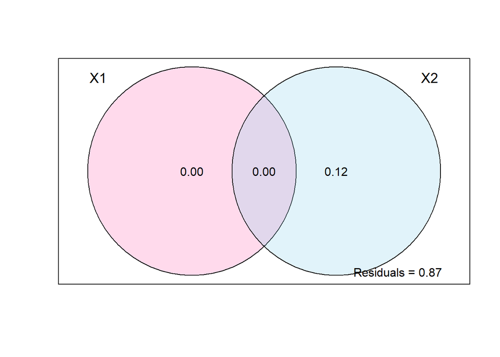

```r
plot(vp_selection, bg = c("hotpink","skyblue"))
```

You could also re-run analysis to get new pvalues from this new reduced PCNMs table.

#### Using Bray-Curtis distance

Now, using the Bray-Curtis distance. The varpart() function can be used in the same way, but fractions tests should now be done using dbrda() method (distance-based rda) as Bray-Curtis is a distance contrary to the Hellinger transform. Also, Bray-Curtis cannot deal with data where some patches are empty. Such data have to be filter before running analysis.

```r
# Filtering dataset
to_remove = apply(snapshot, 1, sum) == 0
if(sum(to_remove)>0){
  snapshot = snapshot[-to_remove,]
  data_envt = data_envt[-to_remove,]
  data_geo = data_geo[-to_remove,]
}
```

VarPart analysis

```r
dist_matrix = dist(data_geo)
pcnms = scores(pcnm(dist_matrix))

vp = varpart(vegdist(snapshot, method = "bray"),
              ~env1+I(env1^2),
              pcnms,
              data = data_envt)
vp
```

```
##
## Partition of squared Bray distance in dbRDA
##
## Call: varpart(Y = vegdist(snapshot, method = "bray"), X = ~env1 +
## I(env1^2), pcnms, data = data_envt)
##
## Explanatory tables:
## X1:  ~env1 + I(env1^2)
## X2:  pcnms
##
## No. of explanatory tables: 2
## Total variation (SS): 47.867
## No. of observations: 249
##
## Partition table:
##                       Df R.squared Adj.R.squared Testable
## [a+c] = X1             2   0.01525       0.00725     TRUE
## [b+c] = X2           146   0.64028       0.12538     TRUE
## [a+b+c] = X1+X2      148   0.64844       0.12814     TRUE
## Individual fractions
## [a] = X1|X2            2                 0.00276     TRUE
## [b] = X2|X1          146                 0.12090     TRUE
## [c]                    0                 0.00448    FALSE
## [d] = Residuals                          0.87186    FALSE
## ---
## Use function 'dbrda' to test significance of fractions of interest
```

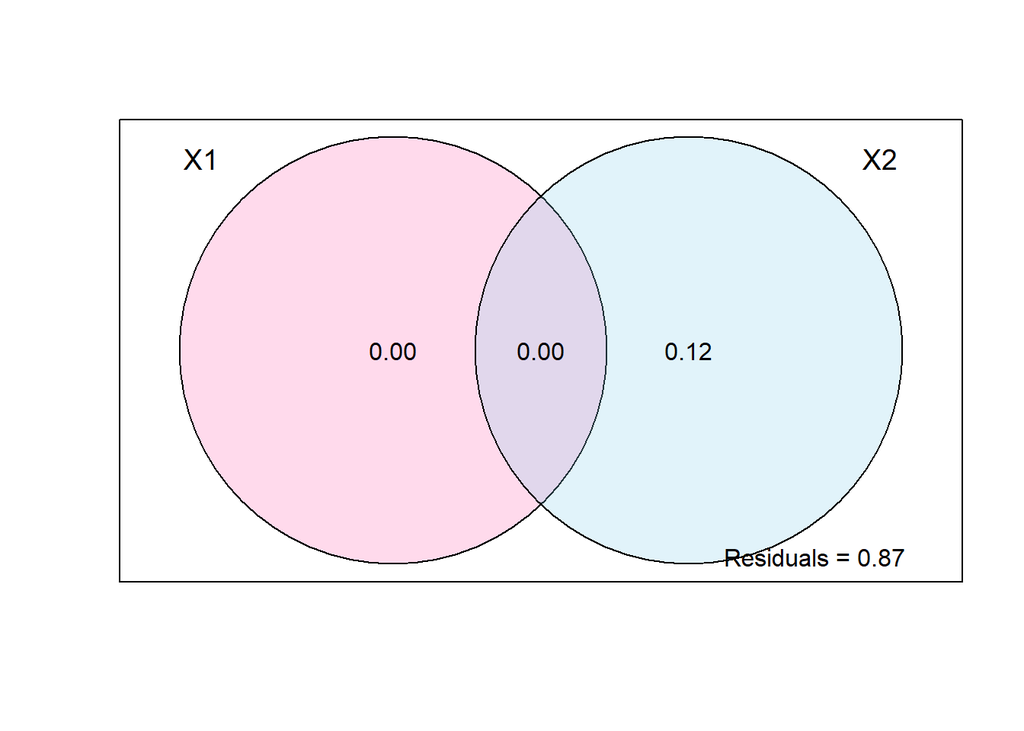

```r
plot(vp, bg = c("hotpink","skyblue"))
```

Testing of partition is then made using dbrda() functions :

```r
frac_envt = dbrda(snapshot ~ env1+I(env1^2),data = data_envt, dist = 'bray')
frac_envt
```

```
## Call: dbrda(formula = snapshot ~ env1 + I(env1^2), data = data_envt,
## distance = "bray")
##
##                Inertia Proportion Rank RealDims
## Total         47.86734    1.00000
## Constrained    0.73007    0.01525    2        2
## Unconstrained 47.13727    0.98475  246       77
## Inertia is squared Bray distance
##
## Eigenvalues for constrained axes:
## dbRDA1 dbRDA2
## 0.4489 0.2811
##
## Eigenvalues for unconstrained axes:
##   MDS1   MDS2   MDS3   MDS4   MDS5   MDS6   MDS7   MDS8
## 21.157 14.771  8.749  4.012  2.153  1.762  1.594  1.448
## (Showing 8 of 246 unconstrained eigenvalues)
```

```r
RsquareAdj(frac_envt)
```

```
## $r.squared
## [1] 0.01525204
##
## $adj.r.squared
## [1] 0.007245957
```

```r
anova(frac_envt)
```

```
## Permutation test for dbrda under reduced model
## Permutation: free
## Number of permutations: 999
##
## Model: dbrda(formula = snapshot ~ env1 + I(env1^2), data = data_envt, distance = "bray")
##           Df SumOfSqs      F Pr(>F)
## Model      2    0.730 1.9051  0.088 .
## Residual 246   47.137
## ---
## Signif. codes:  0 '***' 0.001 '**' 0.01 '*' 0.05 '.' 0.1 ' ' 1
```

```r
# etc. for [x2], [x2|x1], [x1|x2] ...
```

### Practical (for true)

Variation partitioning often used to tease appart effects of environmental variables (as a proxy of niche-based mechanisms) against spatial predictors (as a proxy of dispersal - ~ neutral-based processes).

Using the simulation function above, it’s possible to simulate either fully niche based communities and/or communities constrained by dispersal, while considering spatial autocorrelation for environmental gradient.

- Niche component : small vs. large ‘envt_niche_breadth’ (e.g., 0.1 vs . 1)
- Dispersal component : slow vs. quick decrease rate of disp. kernel ‘kernel_exp’ (0.01 vs. 0.2)
- Environmental auto-correlation : no correlation vs. fully auto correlated ‘env1Scale’ (from 100 to 0.01)

Can try by yourself !

Can also check :

- How adjR2 values & pval change with variable selection ?
- Is there differences between presence/absence based vs. abundance-based approaches ?
- What if another time is used ? (e.g., taken at the beginning of the time serie ?)
- What if initial distribution of each species is spatially clustered (i.e., mimicking an invasion situation)
  - Set the ‘local_start’ argument to TRUE
  - Compare ordination results for very first time steps vs. long-term dyn. equilibrium - e.g., in a case without disp. limitation ?

```r
sim = simulate_MC(patches = n_patch,       # Number of patch
                  species = n_species,     # Number of species
                  env1Scale = 100,           # Spatial autocorrelation for environmental variable (from 1 to 999)
                  env_niche_breadth = 0.1, # Niche effects
                  kernel_exp = 0.001,       # Dispersal not limited by distance
                  local_start = T)
```

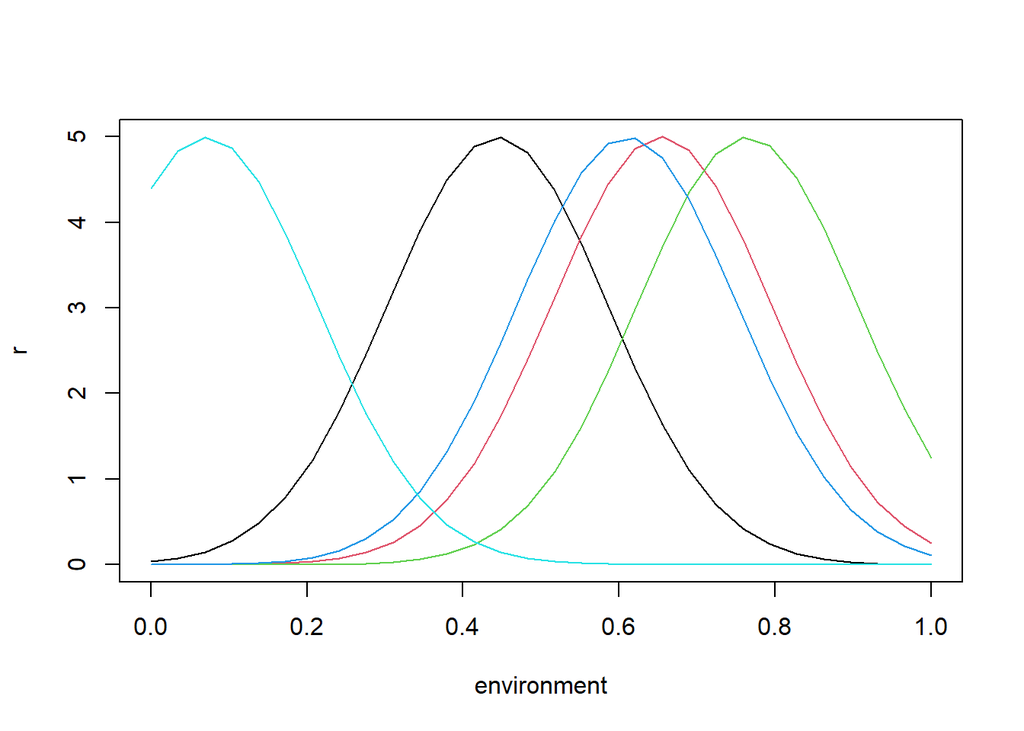

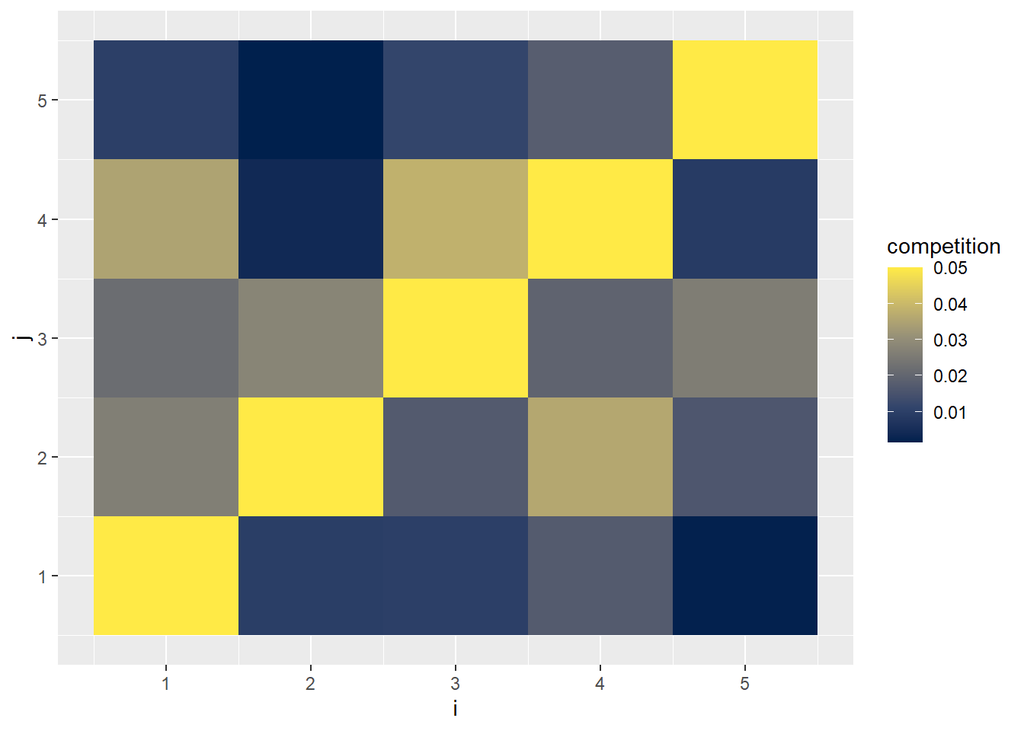

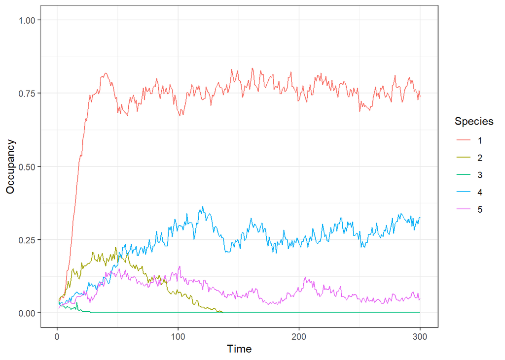

```r
data_envt = get_envt(sim)
data_geo = get_geoposition(sim)

pcnms = scores(pcnm(dist(data_geo)))

abundances = sim_to_matrix(sim)
occupancies = abund_to_occ(abundances)

plots_occupancies(occupancies)
```

Keep a simulation with enough species at equilibrium to be meaningful, and compare e.g., steps 5 vs. steps 250… Can restart several times.

- Tricky one : Which processes are important for this dataset (can be loaded directly with read_rds()) ?

Dataset can be download from https://github.com/mxdub/TMDSpatial_data, and put into a data/ folder in our working folder.

```r
snapshot = read_rds("./data/vp_snap.rds")
pcnms = read_rds('./data/vp_pcnms.rds')
data_envt = read_rds('./data/vp_envt.rds')
```

If we now say, there is in fact, no dispersal limitation ? What could explained such results ?